```r
library(tidyverse)
library(IRdisplay)
```

# Multiple plots

Using aesthetics, we can separately show the cars with different colors and sizes in one graph.

Another way to do this is to split your plot into facets, subplots that each display one type of car.

To facet your plot by a single variable, use `facet_wrap()`

- The first argument of `facet_wrap()` should be a formula
- Formulas are created with `~` followed by a variable name
- The variable that you pass to `facet_wrap()` should be discrete

```
{r}

ggplot(data=mpg) +
   geom_point(mapping = aes(x = displ, y = hwy))+
              facet_wrap(~class, nrow=2)
```

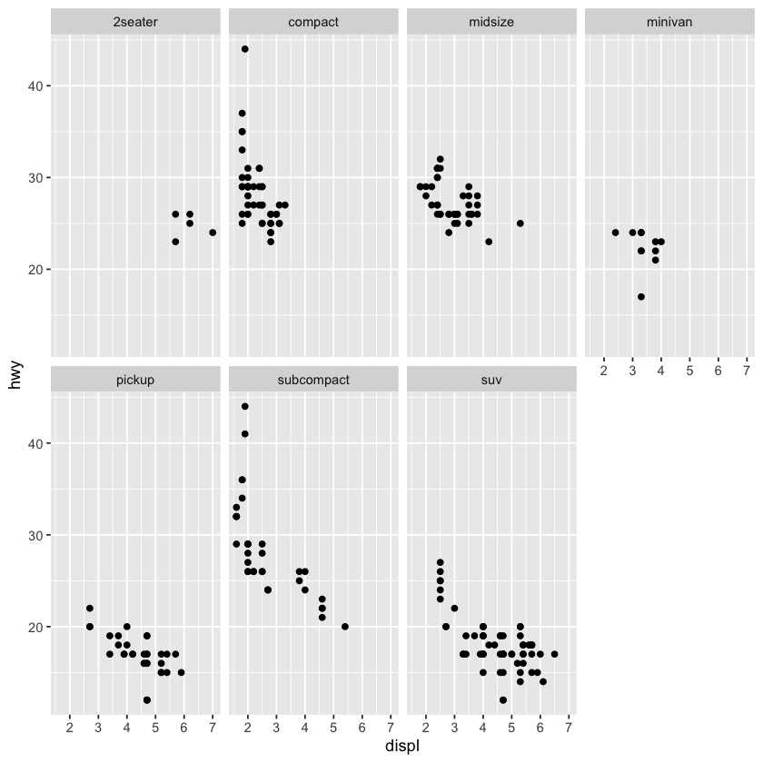

```r
ggplot(data=mpg) +
   geom_point(mapping = aes(x = displ, y = hwy))+
              facet_wrap(~class, nrow=2)
```

# Facet Grid

To facet your plot on the combination of two variables, add `facet_grid()` to your plot call

The first argument of `facet_grid()` is also a formula.

This time the formula should contain two variable names separated by a `~`

```
{r}
ggplot(data = mpg) +
    geom_point(mapping = aes(x = displ, y = hwy)) +
        facet_grid(drv ~ cyl)

ggplot(data = mpg) +
    geom_point(mapping = aes(x = displ, y = hwy)) +
        facet_grid(. ~ cyl)
```

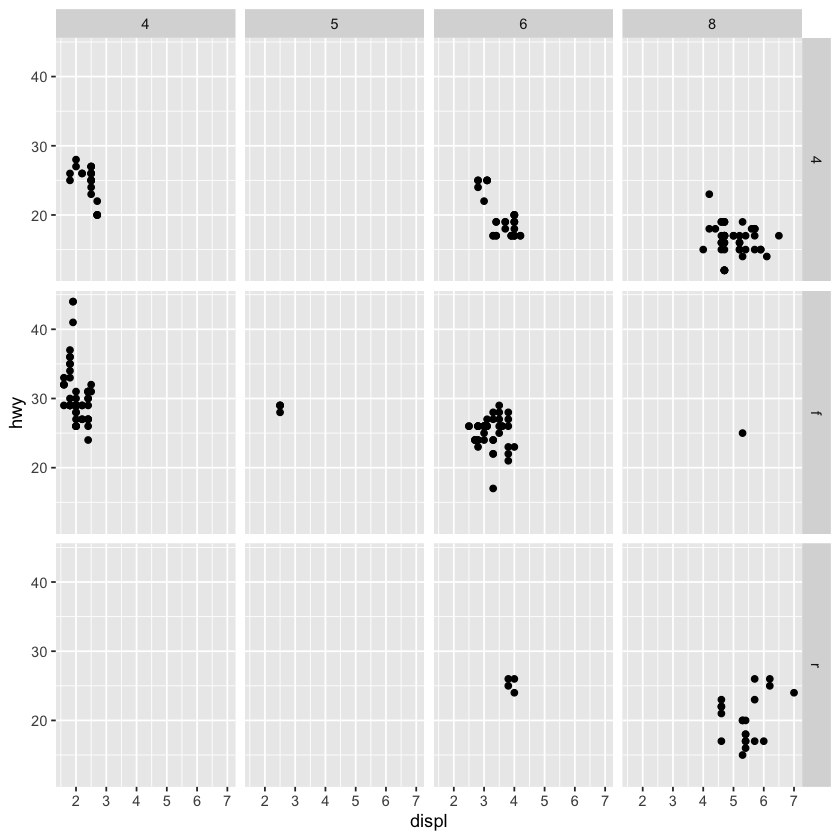

```r
ggplot(data = mpg) +
    geom_point(mapping = aes(x = displ, y = hwy)) +
        facet_grid(drv ~ cyl)
```

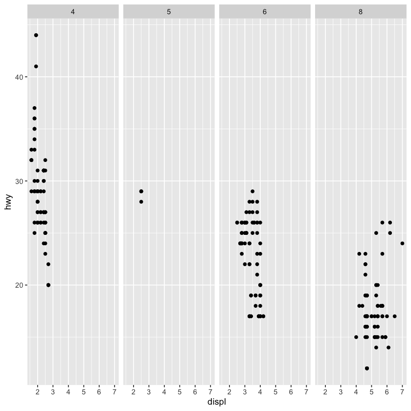

```r
ggplot(data = mpg) +
    geom_point(mapping = aes(x = displ, y = hwy)) +
        facet_grid(. ~ cyl)
```

# Your turn

- What happens if you facet on a numerical variable? (e.g. `cty`)
- Read `?facet_wrap` and try the `scales` argument.
- What are the advantages of using faceting instead of the color aesthetic? What are the disadvantages? How might the balance change if you had a larger dataset?
- When using `facet_grid()`, you can put the variable with more unique levels in the columns or rows. Which is better? (try facet with `class` and `cyl` in two different ways)

# Five graphs

In ggplot2 syntax, different geom functions use different visual objects to represent the data.

A geom is the geometrical object that a plot uses to represent data.

We will focus on five imporant graphs

1. Scatterplots
2. Line graphs
3. Histograms
4. Box plots
5. Bar plots

# Scatterplots

Scatterplots allow you to visualize the relationship between two numerical variables.

```
{r}

ggplot(data = mpg) +
    geom_point(mapping = aes(x = displ, y = hwy))
```

One problem with the scatterpl;ot of `hwy` and `displ` is that the values of `hwy` and `displ` are rounded so the points appear on a grid and many points overlap with each other.

When overplotting occurs, it is difficult to know thte number of points being plotted.

There are two methods to address the issue of overplotting

- Adjusting the transparency of the points
- Adding a little random "jitter", or random "nudges" to each of the points

# Changing the transparency

We can change the transparency by the argument `alpha` in `geom_point()`

The argument can take any value between 0 and 1, where 0 is 100% transparent and 1 is 100% opaque.

```
{r}

ggplot(data = mpg) +
  geom_point(mapping = aes(x = displ, y = hwy),alpha=0.2)
```

# Jittering the points

The second way of addressing overplotting is by jittering all the points.

Jittering means giving each point a small "nudge" in a random direction

```
{r}

ggplot(data = mpg) +
  geom_point(mapping = aes(x = displ, y = hwy),  position="jitter")
```

Keep in mind jittering is strictly a visualization tool:  
Even after creating a jittered scatterplot, the original values saved in the data remain unchanged.

# Your turn

- `position="jitter"` cannot specify how much noise to add.
  - Another way of jittering is to use `geom_jitter()` instead of `geom_point()`
  - Try the following code and use the help page to find out how to control the amount of jittering

  ```
  {r}

  ggplot(data = mpg) +
        geom_jitter(mapping = aes(x = displ, y = hwy))
  ```

- Compare and contrast `geom_jitter()` with `geom_count()`

# Line graphs

Line graphs show the relationship between two numerical variables - Use when the variable on the x-axis, the *explanatory* variable, has an inherent ordering (*sequential*)

## `geom_line`

`geom_line()` connects the points in order of the variable on the x-axis. - Visualizes the trend of the data - Frequently used when time is the explanatory variable on the x-axis.

```
{r}

ggplot(data = mpg) +
 geom_line(mapping = aes(x = displ, y = hwy))
```

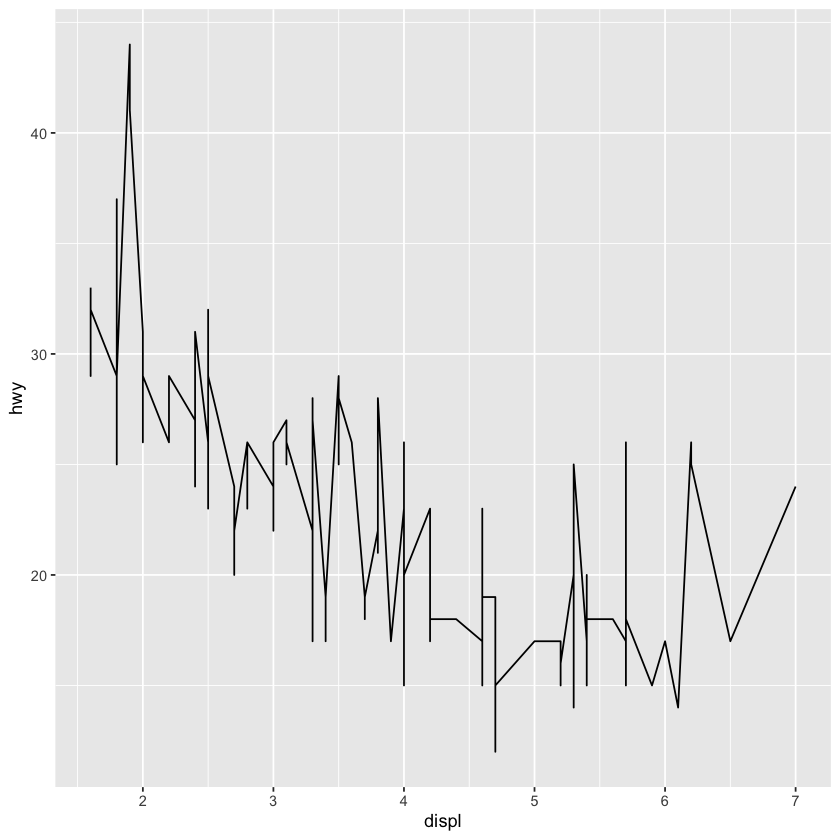

# Your turn

- Replace `geom_line()` with `geom_path()` to see what happens
- Explain the difference.

## `geom_smooth()`

We can plot a smooth line fitted to the data using `geom_smooth()`

```
{r}

ggplot(data = mpg) +
  geom_smooth(mapping = aes(x = displ, y = hwy))
```

Every geom funciton in ggplot2 takes a mapping argument

However, note every aesthetic works with every geom

`geom_smooth()` with draw a different line, with a different linetype, for each unique value of the variable that you map to linetype.

```
{r}

ggplot(data = mpg) +
  geom_smooth(mapping = aes(x = displ, y = hwy,linetype = drv))
```

# Your turn

- Create a graph with both points and smoothed lines and coloring everything (both the points and lines) according to `drv`
- Compare the following two plots:

```
{r}

ggplot(data = mpg) +
  geom_smooth(mapping = aes(x = displ, y = hwy,linetype = drv))

ggplot(data = mpg) +
  geom_smooth(mapping = aes(x = displ, y = hwy,group = drv))
```

# Histograms

We can plot a histogram if we only care about the distribution of one variable

```
1. What are the smallest and largest values?
2. What is the "center" or "most typical" value?
3. How do the values spread out?
4. What are the frequent and infrequent values?
```

A histogram is a plot that visualizes the distribution of a numerical value as follows:

```
 1. We first cut up the x-axis into a series of bins, where each bin represents a range of values.
 2. For each bin, we count the number of observations that fall in the range corresponding to that bin.
 3. Then for each bin, we draw a bar whose height marks the corresponding count.
```

## `geom_histogram()`

```
{r}

ggplot(mpg) +
    geom_histogram(mapping = aes(x = hwy))
```

Unlike scatterplots and linegraphs, there is now only one variable being mapped in `aes()`: the numerical variable `hwy`

The y-aesthetic of a histogram, the count of the observations in each bin, gets computed automatically.

Question: what is the requirement for the type of variable in `x`?

It is hard to distinguish each bin.

We can use `color` argument to add borders.

```
{r}

ggplot(mpg) +
    geom_histogram(mapping = aes(x = hwy), color="white")
```

You can use the `fill` argument to change the color of the bars

```
{r}

ggplot(mpg) +
    geom_histogram(mapping = aes(x = hwy), color = "white", fill = "steelblue")
```

If you're curious, run `colors()` to see all possible choices of colors in R.

## Adjusting the bins

### Adjusting number of bins

We can use the bins argument specify how many bins we would like to cut the x-axis up in.

```
{r}
ggplot(mpg)+
  geom_histogram(mapping = aes(x=hwy),color="white",bins=40)
```

### Adjusting the bin width

We can use the binwidth argument to specify the width of the bins.

```
{r}
ggplot(mpg)+
  geom_histogram(mapping = aes(x=hwy),color="white",binwidth=1)
```

### Setting the boundaries manually

We can use the `breaks` argument to specify the boundaries of the bins.

```
ggplot(mpg)+
  geom_histogram(mapping = aes(x=hwy),color="white",breaks=10:45)
```

# The shape of the distribution

- Determining the shape of your variable is essential before any further analysis is done.
- Statistical methods used for inference often require your data to be distibuted in a certain manner before they can be applied to the data.
- You can describe the shape in terms of:
  - Is it symmetric?
  - How many peaks does it have?
  - Is it skewed to the left or right?
  - Is it close to uniform?

## The Normal Distribution

- Also referred to as the Gaussian distribution
- Very common distribution and is often described as a bell-shaped curve
- Often described as a bell-shaped curve.
- Values are symmetric around the central value
- High density of the values falling right around the central value

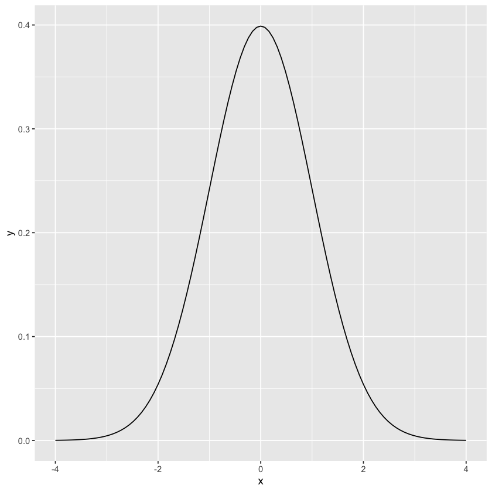

```r
ggplot(data.frame(x = c(-4, 4)), aes(x = x)) +
stat_function(fun = dnorm)
```

## A variable can be described as normally distributed if:

- There is a strong tendency for data to take a central value
- Deviations away from the central value are equally likely in both directions